# Progressives Morphosyntactic Analysis of Textbook Conversation

# Negation

H0: The frequencies of the levels of the dependent variable NEGATION do not vary as a function of the levels of the independent variable CORPUS; X2 = 0

H1: The frequencies of the levels of the dependent variable NEGATION vary as a function of the levels of the independent variable CORPUS; X2 > 0

A chi-square test assumes independent observations which we don’t really have here (lots from same textbook, possibly several from indidivudal speaker in the BNC).

```r
round(prop.table(table(prog$Corpus, prog$Negation), margin = 1), 4)*100
```

```
##
##                         negated positive
##   Spoken BNC2014 sample    6.48    93.52
##   Textbook Conversation    5.08    94.92
```

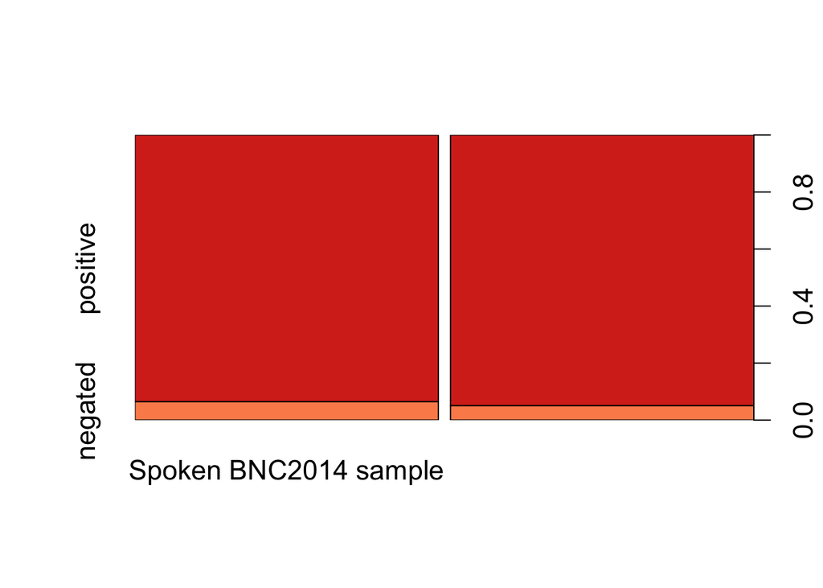

```r
prog$Negation <- relevel(prog$Negation, "positive")

#tiff(here("prog_negation.tiff"), height = 17, width = 20, units="cm", compression = "lzw", res = 300)
par(cex = 1.4, cex.main = 0.85)
plot(prog$Negation ~ prog$Corpus, ylab = "", xlab = "", main = "", col = cols[3:4])
```

```r
dev.off()
```

```r
# No interesting correlation to be seen
#tiff(here("prog_negation_question.tiff", height = 13, width = 20, units="cm", compression = "lzw", res = 300)
par(cex = 1.4, cex.main = 0.85)
vcd::mosaic(Negation ~ Corpus + Question, prog, gp = grid::gpar(fill = cols[4:3]), rot_labels = c(0, 90, 0, 90), cex=2.5, zero_size = 0, labeling_args = list(rep = TRUE)) # Best so far
#dev.off()

negation <- table(prog$Corpus, prog$Negation)

test.negation <- chisq.test(negation); test.negation # Significant correlation at p < 0.05
```

[output not shown]

```
##
##  Pearson's Chi-squared test with Yates' continuity correction
##
## data:  negation
## X-squared = 4.1278, df = 1, p-value = 0.04218
```

```r
assocplot(t(negation))
vcd::assocstats(negation) # Phi-coefficient is only 0.03 = very weak!
```

[output not shown]

```
##                     X^2 df P(> X^2)
## Likelihood Ratio 4.3920  1 0.036109
## Pearson          4.3817  1 0.036326
##
## Phi-Coefficient   : 0.03
## Contingency Coeff.: 0.03
## Cramer's V        : 0.03
```

```r
lsr::associationTest( ~ Negation + Corpus, data = prog) # Cramer's V = 0.03
```

```
##
##      Chi-square test of categorical association
##
## Variables:   Negation, Corpus
##
## Hypotheses:
##    null:        variables are independent of one another
##    alternative: some contingency exists between variables
##
## Observed contingency table:
##           Corpus
## Negation   Spoken BNC2014 sample Textbook Conversation
##   positive                  2266                  2300
##   negated                    157                   123
##
## Expected contingency table under the null hypothesis:
##           Corpus
## Negation   Spoken BNC2014 sample Textbook Conversation
##   positive                  2283                  2283
##   negated                    140                   140
##
## Test results:
##    X-squared statistic:  4.128
##    degrees of freedom:  1
##    p-value:  0.042
##
## Other information:
##    estimated effect size (Cramer's v):  0.029
##    Yates' continuity correction has been applied
```

# Contraction

```r
round(prop.table(table(prog$Corpus, prog$Contraction), margin = 1), 4)*100
```

```
##
##                         contract.  full
##   Spoken BNC2014 sample     53.03 46.97
##   Textbook Conversation     46.43 53.57
```

```r
round(prop.table(table(prog$Textbook, prog$Contraction), 1),4)*100
```

```
##
##                         contract.  full
##   Access                    54.07 45.93
##   Achievers                 42.57 57.43
##   English in Mind           57.02 42.98
##   Green Line                43.17 56.83
##   Hi there                  44.13 55.87
##   Join the Team             29.41 70.59
##   New Green Line            44.50 55.50
##   Piece of cake             39.26 60.74
##   Solutions                 45.72 54.28
##   Spoken BNC2014 sample     53.03 46.97
```

```r
table(prog$Textbook, prog$Contraction)
```

```
##
##                         contract. full
##   Access                      226  192
##   Achievers                    43   58
##   English in Mind             138  104
##   Green Line                   60   79
##   Hi there                     94  119
##   Join the Team                35   84
##   New Green Line              182  227
##   Piece of cake                64   99
##   Solutions                   283  336
##   Spoken BNC2014 sample      1285 1138
```

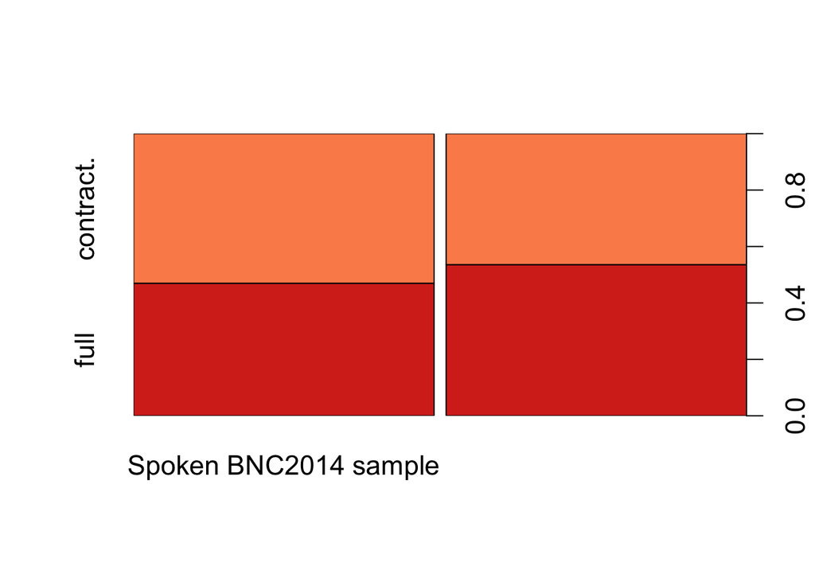

```r
cols<-RColorBrewer::brewer.pal(n=4,name="OrRd")

#tiff(here("prog_contractions.tiff"), height = 25, width = 20, units="cm", compression = "lzw", res = 300)
par(cex = 1.4, cex.main = 0.85)
plot(prog$Contraction ~ prog$Corpus, ylab = "", xlab = "", main = "", col = cols[4:3])

plot(prog$Contraction ~ prog$Corpus, ylab = "", xlab = "", main = "", col = cols[4:3])
```

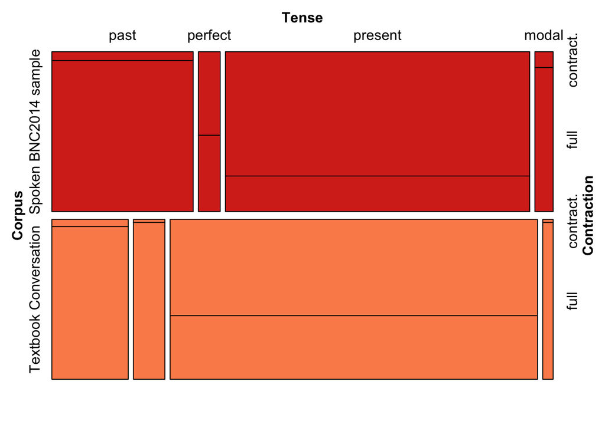

```r
#dev.off()

#tiff(here("prog_contractions_tenses.tiff"), height = 13, width = 20, units="cm", compression = "lzw", res = 300)
par(cex = 1.4, cex.main = 0.85)
vcd::mosaic(Contraction ~ Corpus + Tense, prog, gp = grid::gpar(fill = cols[4:3]), rot_labels = c(0, 90, 0, 90), cex=2.5, zero_size = 0, labeling_args = list(rep = TRUE)) # Best so far
```

```r
#dev.off()

round(prop.table(table(prog$Contraction, prog$Textbook), 2),4)*100
```

```
##
##             Access Achievers English in Mind Green Line Hi there Join the Team
##   contract.  54.07     42.57           57.02      43.17    44.13         29.41
##   full       45.93     57.43           42.98      56.83    55.87         70.59
##
##             New Green Line Piece of cake Solutions Spoken BNC2014 sample
##   contract.          44.50         39.26     45.72                 53.03
##   full               55.50         60.74     54.28                 46.97
```

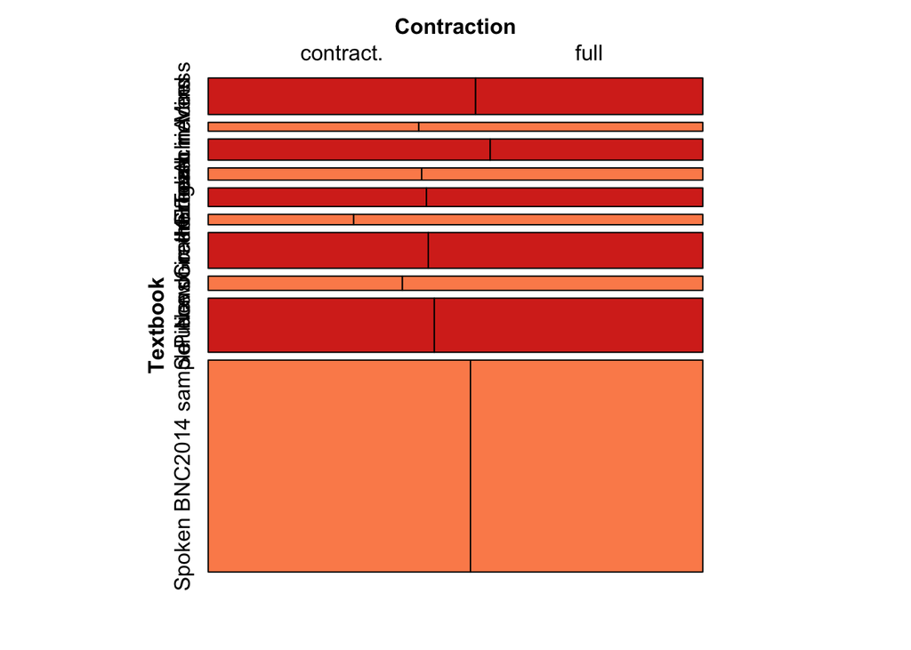

```r
#tiff(here("prog_contractions_series.tiff"), height = 13, width = 20, units="cm", compression = "lzw", res = 300)
par(cex = 1.4, cex.main = 0.85)
vcd::mosaic(Contraction ~ Textbook, prog, gp = grid::gpar(fill = cols[4:3]), rot_labels = c(0, 90, 0, 90), cex=2.5, zero_size = 0, labeling_args = list(rep = TRUE)) # Best so far
```

```r
#dev.off()

contractions <- table(prog$Corpus, prog$Contraction)
test.contractions <- chisq.test(contractions)
test.contractions # Significant correlation
```

```
##
##  Pearson's Chi-squared test with Yates' continuity correction
##
## data:  contractions
## X-squared = 20.868, df = 1, p-value = 4.92e-06
```

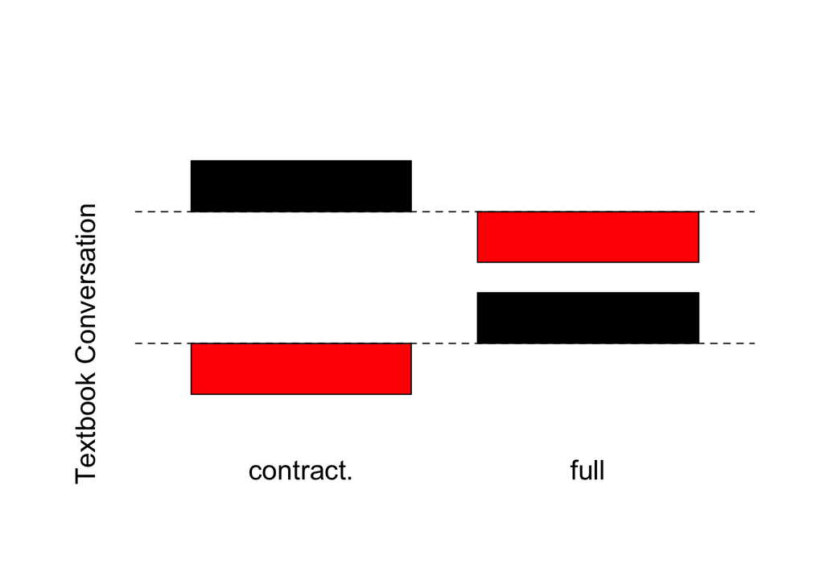

```r
assocplot(t(contractions))
```

```r
vcd::assocstats(contractions) # Phi-coefficient is only 0.066 = very weak!
```

```
##                     X^2 df   P(> X^2)
## Likelihood Ratio 21.147  1 4.2541e-06
## Pearson          21.131  1 4.2883e-06
##
## Phi-Coefficient   : 0.066
## Contingency Coeff.: 0.066
## Cramer's V        : 0.066
```